# **Description**

## **Background and Context**

### Businesses like banks that provide service have to worry about the problem of 'Churn' i.e. customers leaving and joining another service provider. It is important to understand which aspects of the service influence a customer's decision in this regard. Management can concentrate efforts on the improvement of service, keeping in mind these priorities.

## **Objective**

### As a Data Scientist, I will build a neural network-based classifier that can determine whether a bank customer will leave or not in the next 6 months.

## **Data Description**

### The case study is from an open-source dataset from Kaggle. The dataset contains 10,000 sample points with 14 distinct features such as CustomerId, CreditScore, Geography, Gender, Age, Tenure, Balance, etc.

# **Data Dictionary**

## **CustomerId:** Unique ID which is assigned to each customer

## **Surname:** Last name of the customer

## **CreditScore:** It defines the credit history of the customer.

## **Geography:** A customer’s location

## **Gender:** It defines the Gender of the customer

## **Age:** Age of the customer

## **Tenure:** Number of years for which the customer has been with the bank

## **NumOfProducts:** It refers to the number of products that a customer has purchased through the bank.

## **Balance:** Account balance

## **HasCrCard:** It is a categorical variable that decides whether the customer has a credit card or not.

## **EstimatedSalary:** Estimated salary

## **isActiveMember:** It is a categorical variable that decides whether the customer is an active member of the bank or not ( Active member in the sense, using bank products regularly, making transactions, etc )

## **Exited:** It is a categorical variable that decides whether the customer left the bank within six months or not. It can take two values

## 0 = No ( Customer did not leave the bank )

## 1=Yes ( Customer left the bank )

```python
# Libraries to help with reading and manipulating data
import pandas as pd
import numpy as np
# Library to split data
from sklearn.model_selection import train_test_split
# Library to encode the variables
from sklearn import preprocessing
# To plot confusion matrix
from sklearn.metrics import confusion_matrix
# libaries to help with data visualization
import matplotlib.pyplot as plt
import seaborn as sns
# library to import to standardize the data
from sklearn.preprocessing import StandardScaler
from sklearn.preprocessing import MinMaxScaler
import tensorflow

#To import different metrics
from sklearn import metrics
import sklearn
from tensorflow.keras import backend
# Library to avoid the warnings
import warnings
warnings.filterwarnings("ignore")
# importing different functions to build models
from tensorflow.keras.models import Sequential
from tensorflow.keras.layers import Dense
import tensorflow as tf
```

```python
# Libraries to help with reading and manipulating data
import numpy as np
import pandas as pd
# libaries to help with data visualization
import matplotlib.pyplot as pyplot
import matplotlib.pyplot as plt
import seaborn as sns
# Library to split data
from sklearn.model_selection import train_test_split
# library to import to standardize the data
from sklearn.preprocessing import StandardScaler
#To import different metrics
from sklearn.metrics import explained_variance_score, mean_squared_error, r2_score, mean_absolute_error
#Importing classback API
from keras import callbacks
# Importing tensorflow library
import tensorflow as tf
# importing different functions to build models
import keras
from tensorflow.keras.layers import Dense, Dropout,InputLayer
from tensorflow.keras.models import Sequential
# Importing Batch Normalization
from keras.layers import BatchNormalization
# Importing backend
from tensorflow.keras import backend
# Importing shffule
from random import shuffle
from keras.callbacks import ModelCheckpoint

from tensorflow.keras.utils import to_categorical
from tensorflow.keras.callbacks import ModelCheckpoint, ReduceLROnPlateau

# Importing optimizers
from tensorflow.keras.optimizers import Adam
from tensorflow.keras.optimizers import RMSprop
from tensorflow.keras.optimizers import SGD

# Library to avoid the warnings
import warnings
warnings.filterwarnings("ignore")
```

```python
import pandas as pd
import numpy as np
from sklearn.model_selection import train_test_split
from sklearn.preprocessing import LabelEncoder, OneHotEncoder
from sklearn import model_selection
from sklearn.compose import ColumnTransformer
import matplotlib.pyplot as plt
import seaborn as sns
from sklearn.impute import SimpleImputer
import warnings
from sklearn.metrics import confusion_matrix
from sklearn.pipeline import Pipeline
from sklearn.model_selection import GridSearchCV
from sklearn.model_selection import RandomizedSearchCV
import tensorflow as tf
from tensorflow.keras.models import Sequential
from tensorflow.keras.layers import Dense
from tensorflow.keras.layers import Dense, Input, Dropout,BatchNormalization
from tensorflow.keras.wrappers.scikit_learn import KerasClassifier
import random
from tensorflow.keras import backend
random.seed(1)
np.random.seed(1)
tf.random.set_seed(1)
warnings.filterwarnings("ignore")
```

```python
# this will help in making the Python code more structured automatically (good coding practice)
#%load_ext nb_black

# Library to suppress warnings or deprecation notes
import warnings

warnings.filterwarnings("ignore")

# Libraries to help with reading and manipulating data

import pandas as pd
import numpy as np

# Library to split data
from sklearn.model_selection import train_test_split

# libaries to help with data visualization
%matplotlib inline
import matplotlib.pyplot as plt
import seaborn as sns

# Removes the limit for the number of displayed columns
pd.set_option("display.max_columns", None)
# Sets the limit for the number of displayed rows
pd.set_option("display.max_rows", 200)

# Libraries to build decision tree classifier
from sklearn.tree import DecisionTreeClassifier
from sklearn import tree

%matplotlib inline

# To tune different models
from sklearn.model_selection import GridSearchCV

# To get diferent metric scores
from sklearn import metrics
from sklearn.metrics import (
    f1_score,
    accuracy_score,
    recall_score,
    precision_score,
    confusion_matrix,
    plot_confusion_matrix,
    make_scorer,
)
# To undersample and oversample the data
from imblearn.over_sampling import SMOTE
from imblearn.under_sampling import RandomUnderSampler
```

```python
# Import the dataset
bank_data = pd.read_csv('Churn_2.csv')
bank_data.head()
```

|  | RowNumber | CustomerId | Surname | CreditScore | Geography | Gender | Age | Tenure | Balance | NumOfProducts | HasCrCard | IsActiveMember | EstimatedSalary | Exited |
| --- | --- | --- | --- | --- | --- | --- | --- | --- | --- | --- | --- | --- | --- | --- |
| 0 | 1 | 15634602 | Hargrave | 619 | France | Female | 42 | 2 | 0.00 | 1 | 1 | 1 | 101348.88 | 1 |
| 1 | 2 | 15647311 | Hill | 608 | Spain | Female | 41 | 1 | 83807.86 | 1 | 0 | 1 | 112542.58 | 0 |
| 2 | 3 | 15619304 | Onio | 502 | France | Female | 42 | 8 | 159660.80 | 3 | 1 | 0 | 113931.57 | 1 |
| 3 | 4 | 15701354 | Boni | 699 | France | Female | 39 | 1 | 0.00 | 2 | 0 | 0 | 93826.63 | 0 |
| 4 | 5 | 15737888 | Mitchell | 850 | Spain | Female | 43 | 2 | 125510.82 | 1 | 1 | 1 | 79084.10 | 0 |

```python
bank_data.isna().sum() # Checking for null observations
```

```
RowNumber          0
CustomerId         0
Surname            0
CreditScore        0
Geography          0
Gender             0
Age                0
Tenure             0
Balance            0
NumOfProducts      0
HasCrCard          0
IsActiveMember     0
EstimatedSalary    0
Exited             0
dtype: int64
```

```python
bank_data.duplicated().sum()  # Checking for duplicated observations
```

```
0
```

```python
bank_data.info()              # Checking the data information including data types
```

```
<class 'pandas.core.frame.DataFrame'>
RangeIndex: 10000 entries, 0 to 9999
Data columns (total 14 columns):
 #   Column           Non-Null Count  Dtype
---  ------           --------------  -----
 0   RowNumber        10000 non-null  int64
 1   CustomerId       10000 non-null  int64
 2   Surname          10000 non-null  object
 3   CreditScore      10000 non-null  int64
 4   Geography        10000 non-null  object
 5   Gender           10000 non-null  object
 6   Age              10000 non-null  int64
 7   Tenure           10000 non-null  int64
 8   Balance          10000 non-null  float64
 9   NumOfProducts    10000 non-null  int64
 10  HasCrCard        10000 non-null  int64
 11  IsActiveMember   10000 non-null  int64
 12  EstimatedSalary  10000 non-null  float64
 13  Exited           10000 non-null  int64
dtypes: float64(2), int64(9), object(3)
memory usage: 1.1+ MB
```

The object data types are Surname, Geography, and Gender. The remaining features are numeric originally.

```python
bank_data.shape     # Checking the shape or dimension of the dataset
```

```
(10000, 14)
```

There are 10,000 rows and 14 columns originally.

```python
bank_data.nunique() # Checking for unique content or values of each feature
```

```
RowNumber          10000
CustomerId         10000
Surname             2932
CreditScore          460
Geography              3
Gender                 2
Age                   70
Tenure                11
Balance             6382
NumOfProducts          4
HasCrCard              2
IsActiveMember         2
EstimatedSalary     9999
Exited                 2
dtype: int64
```

Row Number, Customer ID are unique identiers. Even though surnames are not unique, they will not help in our analysis as different customers can have similar surnames. Credit Score, Age, Balance, and Estimated Salary appear as continuous variables, while Geography, Gender, Tenure, NumOfProducts, HasCrCard, and IsActiveMember appears as categorical variables.

```python
# RowNumber, CustomerId are unique identifiers and will not help in this analysis.
#Also, Surname is unique and will not help in predicting customers staying or leaving the bank
```

```python
data=bank_data.copy() #Copy data for version control
```

```python
data
```

|  | RowNumber | CustomerId | Surname | CreditScore | Geography | Gender | Age | Tenure | Balance | NumOfProducts | HasCrCard | IsActiveMember | EstimatedSalary | Exited |
| --- | --- | --- | --- | --- | --- | --- | --- | --- | --- | --- | --- | --- | --- | --- |
| 0 | 1 | 15634602 | Hargrave | 619 | France | Female | 42 | 2 | 0.00 | 1 | 1 | 1 | 101348.88 | 1 |
| 1 | 2 | 15647311 | Hill | 608 | Spain | Female | 41 | 1 | 83807.86 | 1 | 0 | 1 | 112542.58 | 0 |
| 2 | 3 | 15619304 | Onio | 502 | France | Female | 42 | 8 | 159660.80 | 3 | 1 | 0 | 113931.57 | 1 |
| 3 | 4 | 15701354 | Boni | 699 | France | Female | 39 | 1 | 0.00 | 2 | 0 | 0 | 93826.63 | 0 |
| 4 | 5 | 15737888 | Mitchell | 850 | Spain | Female | 43 | 2 | 125510.82 | 1 | 1 | 1 | 79084.10 | 0 |
| ... | ... | ... | ... | ... | ... | ... | ... | ... | ... | ... | ... | ... | ... | ... |
| 9995 | 9996 | 15606229 | Obijiaku | 771 | France | Male | 39 | 5 | 0.00 | 2 | 1 | 0 | 96270.64 | 0 |
| 9996 | 9997 | 15569892 | Johnstone | 516 | France | Male | 35 | 10 | 57369.61 | 1 | 1 | 1 | 101699.77 | 0 |
| 9997 | 9998 | 15584532 | Liu | 709 | France | Female | 36 | 7 | 0.00 | 1 | 0 | 1 | 42085.58 | 1 |
| 9998 | 9999 | 15682355 | Sabbatini | 772 | Germany | Male | 42 | 3 | 75075.31 | 2 | 1 | 0 | 92888.52 | 1 |
| 9999 | 10000 | 15628319 | Walker | 792 | France | Female | 28 | 4 | 130142.79 | 1 | 1 | 0 | 38190.78 | 0 |

10000 rows × 14 columns

```python
df=data.drop(columns=["RowNumber","CustomerId","Surname"], axis=1) #Drop columns that are not helping with the analysis.
```

```python
df
```

|  | CreditScore | Geography | Gender | Age | Tenure | Balance | NumOfProducts | HasCrCard | IsActiveMember | EstimatedSalary | Exited |
| --- | --- | --- | --- | --- | --- | --- | --- | --- | --- | --- | --- |
| 0 | 619 | France | Female | 42 | 2 | 0.00 | 1 | 1 | 1 | 101348.88 | 1 |
| 1 | 608 | Spain | Female | 41 | 1 | 83807.86 | 1 | 0 | 1 | 112542.58 | 0 |
| 2 | 502 | France | Female | 42 | 8 | 159660.80 | 3 | 1 | 0 | 113931.57 | 1 |
| 3 | 699 | France | Female | 39 | 1 | 0.00 | 2 | 0 | 0 | 93826.63 | 0 |
| 4 | 850 | Spain | Female | 43 | 2 | 125510.82 | 1 | 1 | 1 | 79084.10 | 0 |
| ... | ... | ... | ... | ... | ... | ... | ... | ... | ... | ... | ... |
| 9995 | 771 | France | Male | 39 | 5 | 0.00 | 2 | 1 | 0 | 96270.64 | 0 |
| 9996 | 516 | France | Male | 35 | 10 | 57369.61 | 1 | 1 | 1 | 101699.77 | 0 |
| 9997 | 709 | France | Female | 36 | 7 | 0.00 | 1 | 0 | 1 | 42085.58 | 1 |
| 9998 | 772 | Germany | Male | 42 | 3 | 75075.31 | 2 | 1 | 0 | 92888.52 | 1 |
| 9999 | 792 | France | Female | 28 | 4 | 130142.79 | 1 | 1 | 0 | 38190.78 | 0 |

10000 rows × 11 columns

```python
df.shape
```

```
(10000, 11)
```

Current data shape/dimension is 10,000 rows and 11 columns.

```python
df["Exited"].value_counts(1)
```

```
0    0.7963
1    0.2037
Name: Exited, dtype: float64
```

The dataset is imbalanced as the classes (1 and 0) are not equal. About 20% of the customers exited, while about 80% remained with the bank.

```python
df.columns # Confirm the current features of the dataset
```

```
Index(['CreditScore', 'Geography', 'Gender', 'Age', 'Tenure', 'Balance',
       'NumOfProducts', 'HasCrCard', 'IsActiveMember', 'EstimatedSalary',
       'Exited'],
      dtype='object')
```

```python
# Let's view the content or classes of each feature
for i in df.columns:
  print("Unique content of",i)
  print(df[i].value_counts())
  print("Total observations in", i, "=", df[i].count())
  print("-"*50)
```

```
Unique content of CreditScore
850    233
678     63
655     54
705     53
667     53
      ...
404      1
351      1
365      1
417      1
419      1
Name: CreditScore, Length: 460, dtype: int64
Total observations in CreditScore = 10000
--------------------------------------------------
Unique content of Geography
France     5014
Germany    2509
Spain      2477
Name: Geography, dtype: int64
Total observations in Geography = 10000
--------------------------------------------------
Unique content of Gender
Male      5457
Female    4543
Name: Gender, dtype: int64
Total observations in Gender = 10000
--------------------------------------------------
Unique content of Age
37    478
38    477
35    474
36    456
34    447
33    442
40    432
39    423
32    418
31    404
41    366
```

[output cut: 118 more lines]

```
            ..
120893.07    1
188377.21    1
55902.93     1
4523.74      1
38190.78     1
Name: EstimatedSalary, Length: 9999, dtype: int64
Total observations in EstimatedSalary = 10000
--------------------------------------------------
Unique content of Exited
0    7963
1    2037
Name: Exited, dtype: int64
Total observations in Exited = 10000
--------------------------------------------------
```

```python
df.columns
```

```
Index(['CreditScore', 'Geography', 'Gender', 'Age', 'Tenure', 'Balance',
       'NumOfProducts', 'HasCrCard', 'IsActiveMember', 'EstimatedSalary',
       'Exited'],
      dtype='object')
```

Categorical data: Geography, Gender, Tenure, NumOfProducts, HasCrCard, IsActiveMember, Exited.

Numerical data: CreditScore, Age, Balance, EstimatedSalary.

```python
df1=df.copy() # For version control
```

```python
df1.head()
```

|  | CreditScore | Geography | Gender | Age | Tenure | Balance | NumOfProducts | HasCrCard | IsActiveMember | EstimatedSalary | Exited |
| --- | --- | --- | --- | --- | --- | --- | --- | --- | --- | --- | --- |
| 0 | 619 | France | Female | 42 | 2 | 0.00 | 1 | 1 | 1 | 101348.88 | 1 |
| 1 | 608 | Spain | Female | 41 | 1 | 83807.86 | 1 | 0 | 1 | 112542.58 | 0 |
| 2 | 502 | France | Female | 42 | 8 | 159660.80 | 3 | 1 | 0 | 113931.57 | 1 |
| 3 | 699 | France | Female | 39 | 1 | 0.00 | 2 | 0 | 0 | 93826.63 | 0 |
| 4 | 850 | Spain | Female | 43 | 2 | 125510.82 | 1 | 1 | 1 | 79084.10 | 0 |

```python
cat_features= ["Geography", "Gender", "Tenure", "NumOfProducts", "HasCrCard", "IsActiveMember"]
```

```python
num_features= ["CreditScore", "Age", "Balance", "EstimatedSalary"]
```

```python
target_feature=["Exited"]
```

```python
#Features that are made up of numbers, whether continuous or categorical
numbered_features=["Tenure", "NumOfProducts", "HasCrCard", "IsActiveMember","CreditScore", "Age", "Balance", "EstimatedSalary"]
```

```python
# Convert categorical features to object type aptly
for i in cat_features:
  df1[i]=df[i].astype("object")
```

```python
df1.info()
```

```
<class 'pandas.core.frame.DataFrame'>
RangeIndex: 10000 entries, 0 to 9999
Data columns (total 11 columns):
 #   Column           Non-Null Count  Dtype
---  ------           --------------  -----
 0   CreditScore      10000 non-null  int64
 1   Geography        10000 non-null  object
 2   Gender           10000 non-null  object
 3   Age              10000 non-null  int64
 4   Tenure           10000 non-null  object
 5   Balance          10000 non-null  float64
 6   NumOfProducts    10000 non-null  object
 7   HasCrCard        10000 non-null  object
 8   IsActiveMember   10000 non-null  object
 9   EstimatedSalary  10000 non-null  float64
 10  Exited           10000 non-null  int64
dtypes: float64(2), int64(3), object(6)
memory usage: 859.5+ KB
```

```python
df1.describe(include="all").T  # Let's check the distribution of the data
```

|  | count | unique | top | freq | mean | std | min | 25% | 50% | 75% | max |
| --- | --- | --- | --- | --- | --- | --- | --- | --- | --- | --- | --- |
| CreditScore | 10000.0 | NaN | NaN | NaN | 650.5288 | 96.653299 | 350.0 | 584.0 | 652.0 | 718.0 | 850.0 |
| Geography | 10000 | 3 | France | 5014 | NaN | NaN | NaN | NaN | NaN | NaN | NaN |
| Gender | 10000 | 2 | Male | 5457 | NaN | NaN | NaN | NaN | NaN | NaN | NaN |
| Age | 10000.0 | NaN | NaN | NaN | 38.9218 | 10.487806 | 18.0 | 32.0 | 37.0 | 44.0 | 92.0 |
| Tenure | 10000.0 | 11.0 | 2.0 | 1048.0 | NaN | NaN | NaN | NaN | NaN | NaN | NaN |
| Balance | 10000.0 | NaN | NaN | NaN | 76485.889288 | 62397.405202 | 0.0 | 0.0 | 97198.54 | 127644.24 | 250898.09 |
| NumOfProducts | 10000.0 | 4.0 | 1.0 | 5084.0 | NaN | NaN | NaN | NaN | NaN | NaN | NaN |
| HasCrCard | 10000.0 | 2.0 | 1.0 | 7055.0 | NaN | NaN | NaN | NaN | NaN | NaN | NaN |
| IsActiveMember | 10000.0 | 2.0 | 1.0 | 5151.0 | NaN | NaN | NaN | NaN | NaN | NaN | NaN |
| EstimatedSalary | 10000.0 | NaN | NaN | NaN | 100090.239881 | 57510.492818 | 11.58 | 51002.11 | 100193.915 | 149388.2475 | 199992.48 |
| Exited | 10000.0 | NaN | NaN | NaN | 0.2037 | 0.402769 | 0.0 | 0.0 | 0.0 | 0.0 | 1.0 |

```python
df.describe(include="all").T  # Let's check the distribution of the data
```

|  | count | unique | top | freq | mean | std | min | 25% | 50% | 75% | max |
| --- | --- | --- | --- | --- | --- | --- | --- | --- | --- | --- | --- |
| CreditScore | 10000.0 | NaN | NaN | NaN | 650.5288 | 96.653299 | 350.0 | 584.0 | 652.0 | 718.0 | 850.0 |
| Geography | 10000 | 3 | France | 5014 | NaN | NaN | NaN | NaN | NaN | NaN | NaN |
| Gender | 10000 | 2 | Male | 5457 | NaN | NaN | NaN | NaN | NaN | NaN | NaN |
| Age | 10000.0 | NaN | NaN | NaN | 38.9218 | 10.487806 | 18.0 | 32.0 | 37.0 | 44.0 | 92.0 |
| Tenure | 10000.0 | NaN | NaN | NaN | 5.0128 | 2.892174 | 0.0 | 3.0 | 5.0 | 7.0 | 10.0 |
| Balance | 10000.0 | NaN | NaN | NaN | 76485.889288 | 62397.405202 | 0.0 | 0.0 | 97198.54 | 127644.24 | 250898.09 |
| NumOfProducts | 10000.0 | NaN | NaN | NaN | 1.5302 | 0.581654 | 1.0 | 1.0 | 1.0 | 2.0 | 4.0 |
| HasCrCard | 10000.0 | NaN | NaN | NaN | 0.7055 | 0.45584 | 0.0 | 0.0 | 1.0 | 1.0 | 1.0 |
| IsActiveMember | 10000.0 | NaN | NaN | NaN | 0.5151 | 0.499797 | 0.0 | 0.0 | 1.0 | 1.0 | 1.0 |
| EstimatedSalary | 10000.0 | NaN | NaN | NaN | 100090.239881 | 57510.492818 | 11.58 | 51002.11 | 100193.915 | 149388.2475 | 199992.48 |
| Exited | 10000.0 | NaN | NaN | NaN | 0.2037 | 0.402769 | 0.0 | 0.0 | 0.0 | 0.0 | 1.0 |

# Univariate Data Analysis

```python
# function to plot a boxplot and a histogram along the same scale.


def histogram_boxplot(data, feature, figsize=(12, 7), kde=False, bins=None):
    """
    Boxplot and histogram combined

    data: dataframe
    feature: dataframe column
    figsize: size of figure (default (12,7))
    kde: whether to show the density curve (default False)
    bins: number of bins for histogram (default None)
    """
    f2, (ax_box2, ax_hist2) = plt.subplots(
        nrows=2,  # Number of rows of the subplot grid= 2
        sharex=True,  # x-axis will be shared among all subplots
        gridspec_kw={"height_ratios": (0.25, 0.75)},
        figsize=figsize,
    )  # creating the 2 subplots
    sns.boxplot(
        data=data, x=feature, ax=ax_box2, showmeans=True, color="violet"
    )  # boxplot will be created and a star will indicate the mean value of the column
    sns.histplot(
        data=data, x=feature, kde=kde, ax=ax_hist2, bins=bins, palette="winter"
    ) if bins else sns.histplot(
        data=data, x=feature, kde=kde, ax=ax_hist2
    )  # For histogram
    ax_hist2.axvline(
        data[feature].mean(), color="green", linestyle="--"
    )  # Add mean to the histogram
    ax_hist2.axvline(
        data[feature].median(), color="black", linestyle="-"
    )  # Add median to the histogram
```

```python
# function to create labeled barplots


def labeled_barplot(data, feature, perc=False, n=None):
    """
    Barplot with percentage at the top

    data: dataframe
    feature: dataframe column
    perc: whether to display percentages instead of count (default is False)
    n: displays the top n category levels (default is None, i.e., display all levels)
    """

    total = len(data[feature])  # length of the column
    count = data[feature].nunique()
    if n is None:
        plt.figure(figsize=(count + 1, 5))
    else:
        plt.figure(figsize=(n + 1, 5))

    plt.xticks(rotation=90, fontsize=15)
    ax = sns.countplot(
        data=data,
        x=feature,
        palette="Paired",
        order=data[feature].value_counts().index[:n].sort_values(ascending=True),
    )

    for p in ax.patches:
        if perc == True:
            label = "{:.1f}%".format(
                100 * p.get_height() / total
            )  # percentage of each class of the category
        else:
            label = p.get_height()  # count of each level of the category

        x = p.get_x() + p.get_width() / 2  # width of the plot
        y = p.get_height()  # height of the plot

        ax.annotate(
            label,
            (x, y),
            ha="center",
            va="center",
            size=12,
            xytext=(0, 5),
            textcoords="offset points",
        )  # annotate the percentage

    plt.show()  # show the plot
```

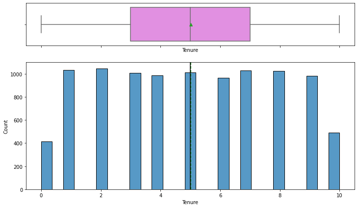

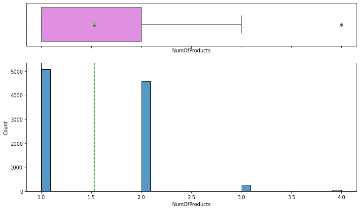

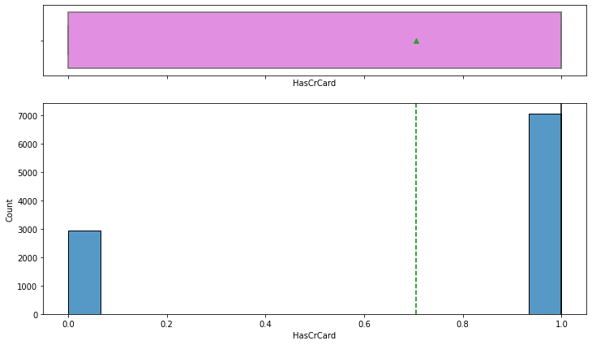

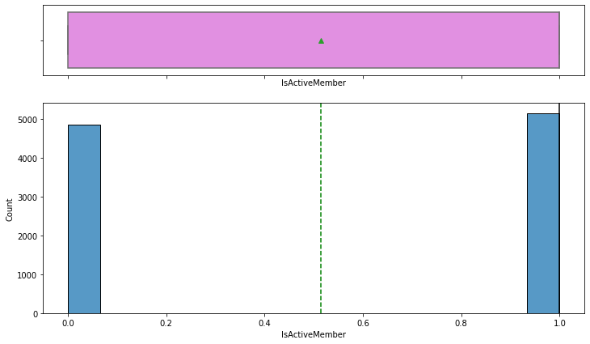

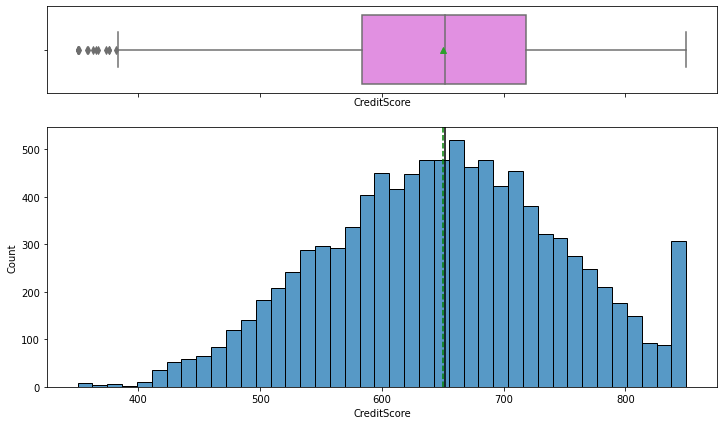

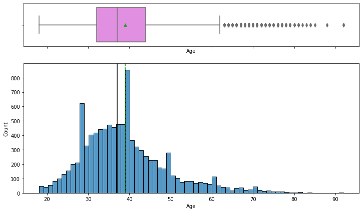

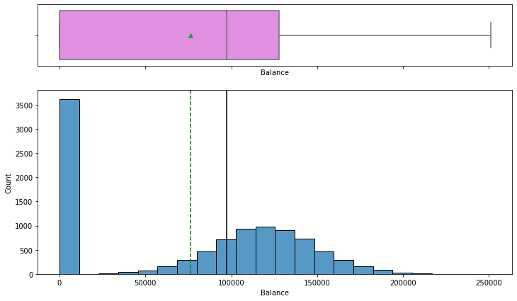

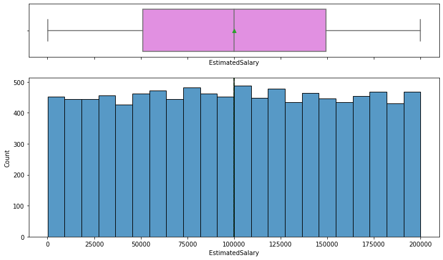

```python
for i in numbered_features:
  histogram_boxplot(data,i)
```

## Outlier Treatment

```python
data[data.Age> 62].describe().T
```

|  | count | mean | std | min | 25% | 50% | 75% | max |
| --- | --- | --- | --- | --- | --- | --- | --- | --- |
| RowNumber | 359.0 | 5.101150e+03 | 2837.281089 | 59.0 | 2905.5 | 4967.00 | 7.589000e+03 | 9937.00 |
| CustomerId | 359.0 | 1.569174e+07 | 74398.834589 | 15566689.0 | 15629371.5 | 15684769.00 | 1.575990e+07 | 15815626.00 |
| CreditScore | 359.0 | 6.570056e+02 | 95.515713 | 408.0 | 596.0 | 657.00 | 7.200000e+02 | 850.00 |
| Age | 359.0 | 6.927019e+01 | 5.237059 | 63.0 | 65.0 | 68.00 | 7.200000e+01 | 92.00 |
| Tenure | 359.0 | 4.944290e+00 | 2.982671 | 0.0 | 2.0 | 5.00 | 8.000000e+00 | 10.00 |
| Balance | 359.0 | 7.447757e+04 | 62335.296038 | 0.0 | 0.0 | 95039.12 | 1.263900e+05 | 187013.13 |
| NumOfProducts | 359.0 | 1.509749e+00 | 0.583085 | 1.0 | 1.0 | 1.00 | 2.000000e+00 | 4.00 |
| HasCrCard | 359.0 | 7.130919e-01 | 0.452950 | 0.0 | 0.0 | 1.00 | 1.000000e+00 | 1.00 |
| IsActiveMember | 359.0 | 8.356546e-01 | 0.371106 | 0.0 | 1.0 | 1.00 | 1.000000e+00 | 1.00 |
| EstimatedSalary | 359.0 | 9.788325e+04 | 57499.034723 | 502.7 | 49530.1 | 97893.40 | 1.458738e+05 | 199493.38 |
| Exited | 359.0 | 2.033426e-01 | 0.403047 | 0.0 | 0.0 | 0.00 | 0.000000e+00 | 1.00 |

Age is 68 on the average and the dataset represents older adults whose activities with the bank would obviously be different compared to the younger customers. At least 75% of the older customers have remained with the bank, accumulated a high credit score on the average of 657, and active members.

```python
data[data.CreditScore<360].describe().T
```

|  | count | mean | std | min | 25% | 50% | 75% | max |
| --- | --- | --- | --- | --- | --- | --- | --- | --- |
| RowNumber | 8.0 | 4.553250e+03 | 3735.515101 | 1406.00 | 1787.25 | 2218.50 | 8733.75 | 9625.00 |
| CustomerId | 8.0 | 1.570813e+07 | 62326.651674 | 15612494.00 | 15676514.00 | 15688894.00 | 15760403.00 | 15803202.00 |
| CreditScore | 8.0 | 3.522500e+02 | 3.882194 | 350.00 | 350.00 | 350.00 | 352.75 | 359.00 |
| Age | 8.0 | 4.962500e+01 | 7.799954 | 39.00 | 43.00 | 51.50 | 54.75 | 60.00 |
| Tenure | 8.0 | 4.000000e+00 | 3.741657 | 0.00 | 0.75 | 3.50 | 6.50 | 10.00 |
| Balance | 8.0 | 1.011183e+05 | 65129.184597 | 0.00 | 82299.90 | 119923.27 | 145826.14 | 163146.46 |
| NumOfProducts | 8.0 | 1.375000e+00 | 0.744024 | 1.00 | 1.00 | 1.00 | 1.25 | 3.00 |
| HasCrCard | 8.0 | 7.500000e-01 | 0.462910 | 0.00 | 0.75 | 1.00 | 1.00 | 1.00 |
| IsActiveMember | 8.0 | 3.750000e-01 | 0.517549 | 0.00 | 0.00 | 0.00 | 1.00 | 1.00 |
| EstimatedSalary | 8.0 | 1.482567e+05 | 27481.648805 | 113796.15 | 125268.37 | 144457.41 | 170296.57 | 191973.49 |
| Exited | 8.0 | 1.000000e+00 | 0.000000 | 1.00 | 1.00 | 1.00 | 1.00 | 1.00 |

Customers with credit score below 360 are between 39-60 years of Age. They have all exited the bank, and had relatively low credit score on the average of 350, even though their estimated salary is at least £113796. We will eliminate this set of customers from the dataset before building the machine learning model as they represent outliers.

```python
data[data.NumOfProducts> 3.0].describe().T
```

|  | count | mean | std | min | 25% | 50% | 75% | max |
| --- | --- | --- | --- | --- | --- | --- | --- | --- |
| RowNumber | 60.0 | 5.175183e+03 | 2717.959089 | 8.00 | 2617.25 | 4.786000e+03 | 7.600750e+03 | 9566.00 |
| CustomerId | 60.0 | 1.567663e+07 | 68148.400931 | 15568006.00 | 15623643.25 | 1.566502e+07 | 1.572067e+07 | 15815316.00 |
| CreditScore | 60.0 | 6.535833e+02 | 101.265600 | 376.00 | 595.00 | 6.430000e+02 | 7.080000e+02 | 850.00 |
| Age | 60.0 | 4.568333e+01 | 8.619040 | 29.00 | 40.00 | 4.500000e+01 | 5.025000e+01 | 68.00 |
| Tenure | 60.0 | 5.300000e+00 | 2.947564 | 1.00 | 2.75 | 5.000000e+00 | 8.000000e+00 | 10.00 |
| Balance | 60.0 | 9.373314e+04 | 57507.383750 | 0.00 | 65787.32 | 1.168082e+05 | 1.315895e+05 | 195238.29 |
| NumOfProducts | 60.0 | 4.000000e+00 | 0.000000 | 4.00 | 4.00 | 4.000000e+00 | 4.000000e+00 | 4.00 |
| HasCrCard | 60.0 | 6.833333e-01 | 0.469102 | 0.00 | 0.00 | 1.000000e+00 | 1.000000e+00 | 1.00 |
| IsActiveMember | 60.0 | 4.833333e-01 | 0.503939 | 0.00 | 0.00 | 0.000000e+00 | 1.000000e+00 | 1.00 |
| EstimatedSalary | 60.0 | 1.047637e+05 | 57526.494114 | 5669.31 | 62033.39 | 1.121631e+05 | 1.393720e+05 | 198874.52 |
| Exited | 60.0 | 1.000000e+00 | 0.000000 | 1.00 | 1.00 | 1.000000e+00 | 1.000000e+00 | 1.00 |

## Lets check the bar plots for each feature

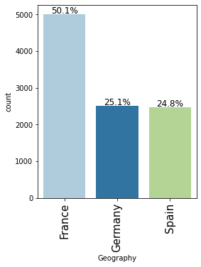

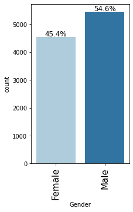

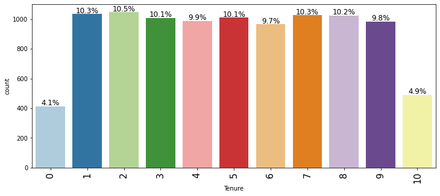

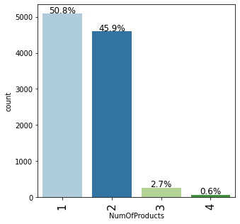

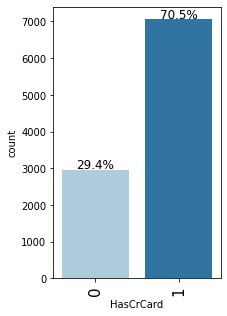

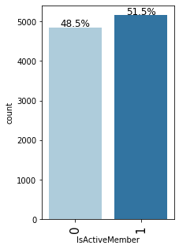

```python
for i in cat_features:
    labeled_barplot(data, i, perc=True)
```

```python
numbered_features
```

```
['Tenure',
 'NumOfProducts',
 'HasCrCard',
 'IsActiveMember',
 'CreditScore',
 'Age',
 'Balance',
 'EstimatedSalary']
```

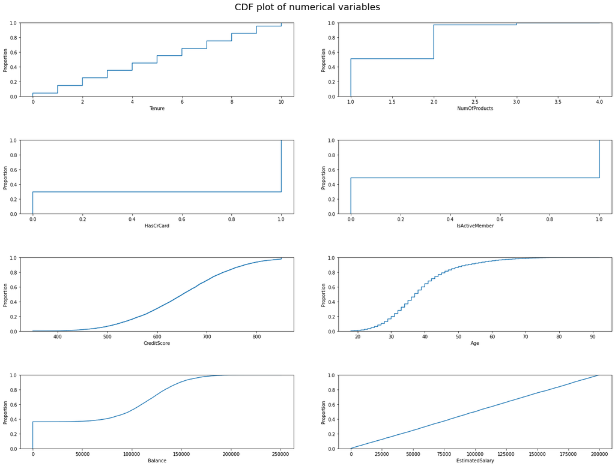

```python
fig, axes = plt.subplots(4, 2, figsize=(20, 15))
fig.suptitle("CDF plot of numerical variables", fontsize=20)
counter = 0
for ii in range(4):
    sns.ecdfplot(ax=axes[ii][0], x=df[numbered_features[counter]])
    counter = counter + 1
    if counter != 8:
        sns.ecdfplot(ax=axes[ii][1], x=df[numbered_features[counter]])
        counter = counter + 1
    else:
        pass

fig.tight_layout(pad=6.0)
```

```python
df.describe().T
```

|  | count | mean | std | min | 25% | 50% | 75% | max |
| --- | --- | --- | --- | --- | --- | --- | --- | --- |
| CreditScore | 10000.0 | 650.528800 | 96.653299 | 350.00 | 584.00 | 652.000 | 718.0000 | 850.00 |
| Age | 10000.0 | 38.921800 | 10.487806 | 18.00 | 32.00 | 37.000 | 44.0000 | 92.00 |
| Tenure | 10000.0 | 5.012800 | 2.892174 | 0.00 | 3.00 | 5.000 | 7.0000 | 10.00 |
| Balance | 10000.0 | 76485.889288 | 62397.405202 | 0.00 | 0.00 | 97198.540 | 127644.2400 | 250898.09 |
| NumOfProducts | 10000.0 | 1.530200 | 0.581654 | 1.00 | 1.00 | 1.000 | 2.0000 | 4.00 |
| HasCrCard | 10000.0 | 0.705500 | 0.455840 | 0.00 | 0.00 | 1.000 | 1.0000 | 1.00 |
| IsActiveMember | 10000.0 | 0.515100 | 0.499797 | 0.00 | 0.00 | 1.000 | 1.0000 | 1.00 |
| EstimatedSalary | 10000.0 | 100090.239881 | 57510.492818 | 11.58 | 51002.11 | 100193.915 | 149388.2475 | 199992.48 |
| Exited | 10000.0 | 0.203700 | 0.402769 | 0.00 | 0.00 | 0.000 | 0.0000 | 1.00 |

# Bivariate Data Analysis

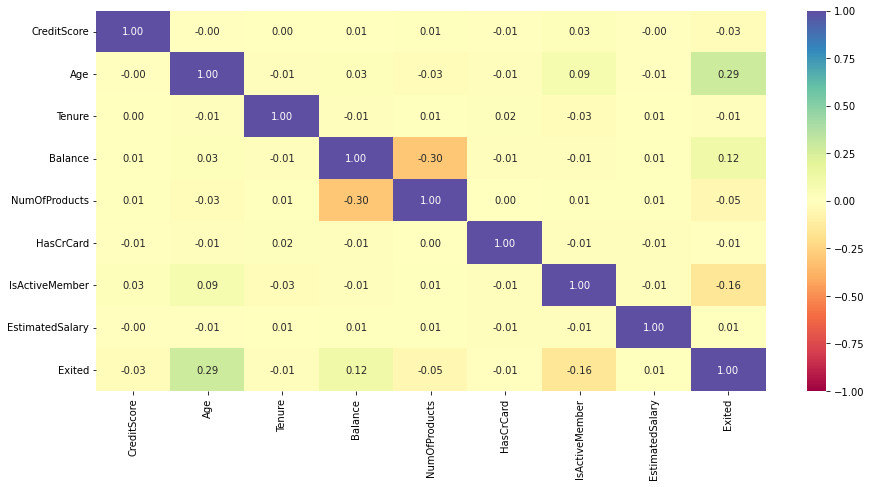

```python
plt.figure(figsize=(15, 7))
sns.heatmap(df.corr(), annot=True, vmin=-1, vmax=1, fmt=".2f", cmap="Spectral")
plt.show()
```

- There is no strong correlation between any of the variables.
- Relatively, there is a positive correlation between Age and Exited (0.29); a negative correlation between Balance and NumOfProducts (-0.30); and a negative correlation between IsActiveMember and Exited (-0.16).
- Even though these correlations are not strong, one can infer that as age of a customer increases they tend to exit the bank as they begin to feel dissatisfied as their status gets higher and personal concern for their financial security after they retire.
- Also, Customers with higher balance use fewer number of products as they are not investing much into more products, they have more active balances in their accounts.
- Finally, customers that are active members may not want to exit as they appear to be loyal customers.

```python
df.columns
```

```
Index(['CreditScore', 'Geography', 'Gender', 'Age', 'Tenure', 'Balance',
       'NumOfProducts', 'HasCrCard', 'IsActiveMember', 'EstimatedSalary',
       'Exited'],
      dtype='object')
```

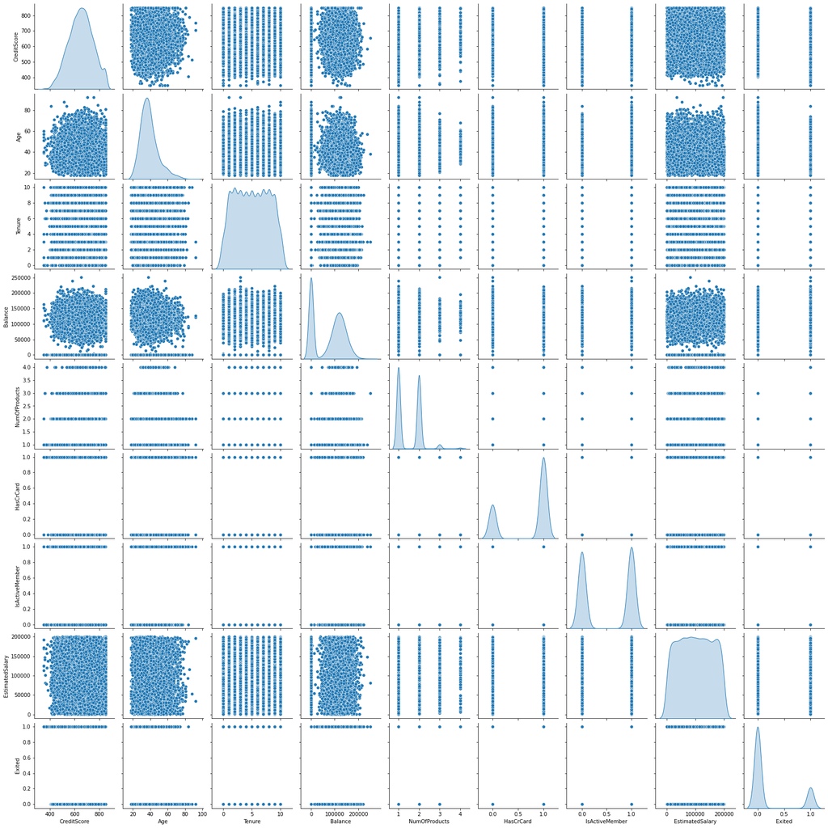

```python
 # To confirm the correlation, let's make a pairplot

sns.pairplot(data=df, diag_kind="kde")
plt.show()
```

- The pair plot shows that Credit Score is fairly normally distributed.
- The pair plot shows that Tenure is not normally distributed, but quite uniformly distributed and similar to the distribution of EstimatedSalary.
- The plot confirms that there is no significant correlation between any of the variables.

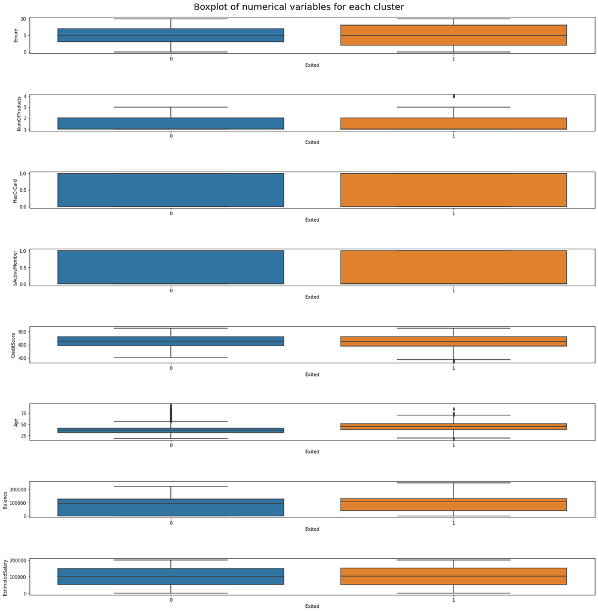

```python
fig, axes = plt.subplots(8, 1, figsize=(20, 20))
fig.suptitle("Boxplot of numerical variables for each cluster", fontsize=20)
counter = 0
for ii in range(8):
    sns.boxplot(ax=axes[ii], y=data[numbered_features[ii]], x=data["Exited"])
    #counter = counter + 1

fig.tight_layout(pad=6.0)
```

- The box plot confirms that on the average more older people exited the bank compared to those that remained with the bank. So, age appears to be a major factor for a customer exiting or staying with the bank.
- On the average, other variables are indifferent to a customer exiting or remaining with the bank.

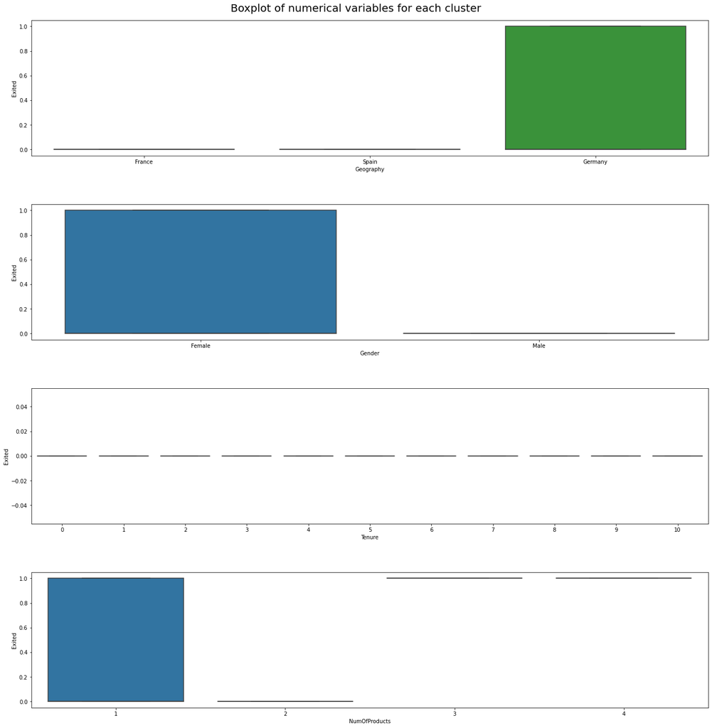

```python
fig, axes = plt.subplots(4, 1, figsize=(20, 20))
fig.suptitle("Boxplot of numerical variables for each cluster", fontsize=20)
counter = 0
for ii in range(4):
    sns.boxplot(ax=axes[ii], y=data['Exited'], x=data[cat_features[ii]],showfliers=False)
    #counter = counter + 1

fig.tight_layout(pad=6.0)
```

- More Germans exited.
- More Females exited compared to male.
- Most people on two products remained with the bank.

```
Exited               0            1      All
Geography
France     4204.000000   810.000000   5014.0
Germany    1695.000000   814.000000   2509.0
Spain      2064.000000   413.000000   2477.0
All        7963.000000  2037.000000  10000.0
France        0.838452     0.161548      NaN
Germany       0.675568     0.324432      NaN
Spain         0.833266     0.166734      NaN
All           0.796300     0.203700      NaN
----------------------------------------------------------------------------------------------------
Exited            0            1      All
Gender
Female  3404.000000  1139.000000   4543.0
Male    4559.000000   898.000000   5457.0
All     7963.000000  2037.000000  10000.0
Female     0.749285     0.250715      NaN
Male       0.835441     0.164559      NaN
All        0.796300     0.203700      NaN
----------------------------------------------------------------------------------------------------
Exited            0            1      All
Tenure
0        318.000000    95.000000    413.0
1        803.000000   232.000000   1035.0
2        847.000000   201.000000   1048.0
3        796.000000   213.000000   1009.0
4        786.000000   203.000000    989.0
5        803.000000   209.000000   1012.0
6        771.000000   196.000000    967.0
7        851.000000   177.000000   1028.0
8        828.000000   197.000000   1025.0
9        771.000000   213.000000    984.0
10       389.000000   101.000000    490.0
All     7963.000000  2037.000000  10000.0
0          0.769976     0.230024      NaN
1          0.775845     0.224155      NaN
2          0.808206     0.191794      NaN
3          0.788900     0.211100      NaN
4          0.794742     0.205258      NaN
5          0.793478     0.206522      NaN
```

[output cut: 23 more lines]

```
1          5631.000000  1424.000000   7055.0
All        7963.000000  2037.000000  10000.0
0             0.791851     0.208149      NaN
1             0.798157     0.201843      NaN
All           0.796300     0.203700      NaN
----------------------------------------------------------------------------------------------------
Exited                    0            1      All
IsActiveMember
0               3547.000000  1302.000000   4849.0
1               4416.000000   735.000000   5151.0
All             7963.000000  2037.000000  10000.0
0                  0.731491     0.268509      NaN
1                  0.857309     0.142691      NaN
All                0.796300     0.203700      NaN
----------------------------------------------------------------------------------------------------
```

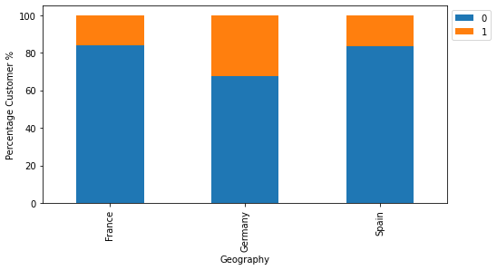

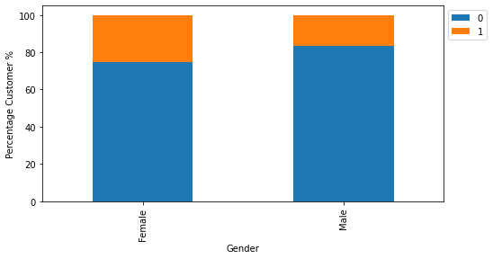

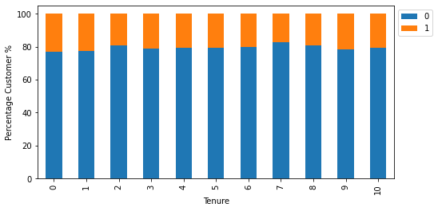

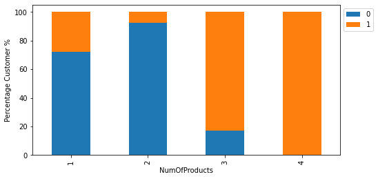

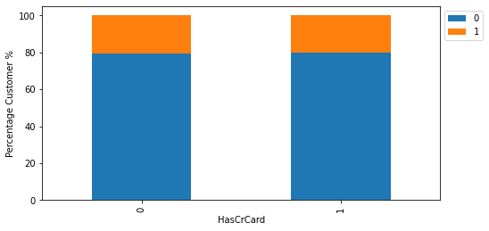

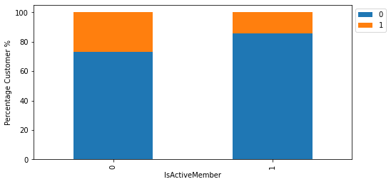

```python
for i in cat_features:
  count = data[i].nunique()
  sorter = data["Exited"].value_counts().index[-1]
  tab1 = pd.crosstab(
      data[i], data["Exited"], normalize="index", margins=True
  )
  tab2 = pd.crosstab(data[i], data["Exited"], margins=True)
  print(pd.concat([tab2, tab1]))
  print("-" * 100)
  # print(tab1)

  (pd.crosstab(data[i], data["Exited"], normalize="index") * 100).plot(
      kind="bar", figsize=(8, 4), stacked=True
  )
  plt.ylabel("Percentage Customer %")
  plt.legend(
      loc="lower left", frameon=False,
  )
  plt.legend(loc="upper left", bbox_to_anchor=(1, 1))
```

- More Germans exited.
- More Females exited compared to male.
- Most people on two products remained with the bank.
- More non-active members exited the bank.

```python
df.columns
```

```
Index(['CreditScore', 'Geography', 'Gender', 'Age', 'Tenure', 'Balance',
       'NumOfProducts', 'HasCrCard', 'IsActiveMember', 'EstimatedSalary',
       'Exited'],
      dtype='object')
```

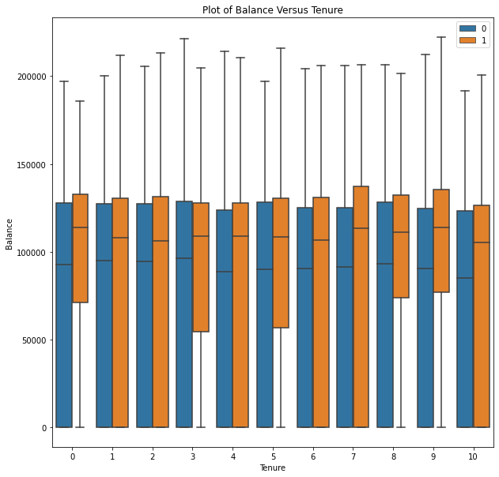

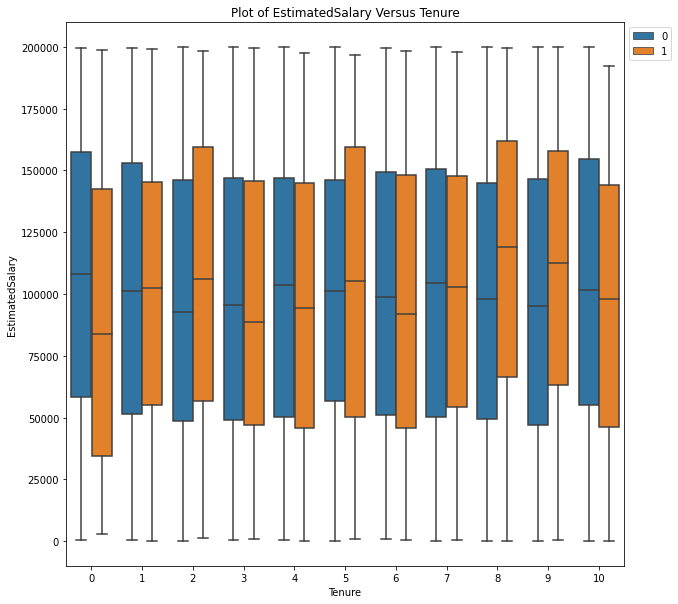

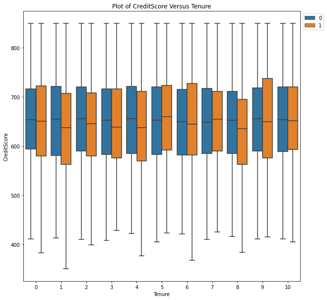

```python
money=["Balance","EstimatedSalary","CreditScore"]
for i in money:
  plt.figure(figsize = (10, 10))

  sns.boxplot(data = df,

             x = 'Tenure',

             y = df[i],

             hue = 'Exited',showfliers=False)

  plt.legend(bbox_to_anchor=(1, 1))

  plt.title("Plot of {} Versus Tenure".format(i))
 # plt.legend(bbox_to_anchor=(1, 1))


  plt.show()
```

- Customers that exited the bank had more balance in their accounts for all the tenures.
- Out of all the customers that exited those in 8-9 tenure have higher estimated salary.
- More customers with lower credit score for majority of the tenure exited compared to those with higher credit score within same tenure, except in tenure 5 and 7.

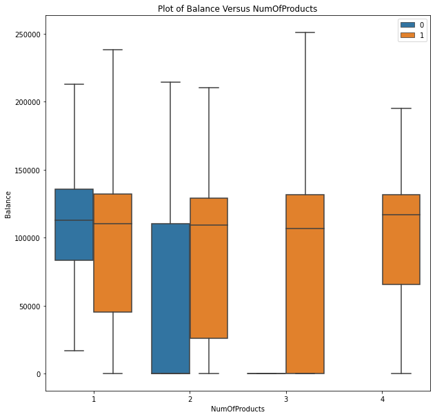

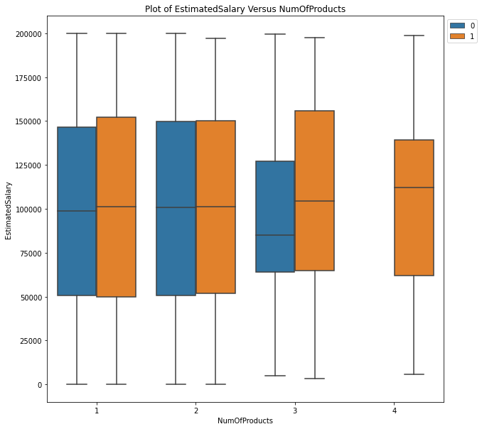

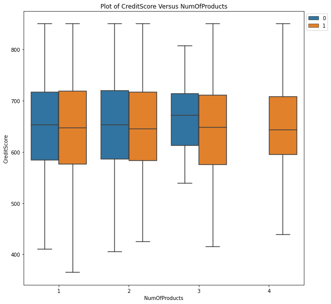

```python
money=["Balance","EstimatedSalary","CreditScore"]
for i in money:
  plt.figure(figsize = (10, 10))

  sns.boxplot(data = df,

             x = 'NumOfProducts',

             y = df[i],

             hue = 'Exited',showfliers=False)

  plt.legend(bbox_to_anchor=(1, 1))

  plt.title("Plot of {} Versus NumOfProducts".format(i))
 # plt.legend(bbox_to_anchor=(1, 1))


  plt.show()
```

- Customers with higher balance exited except those on a single product.
- For all the products, customers with higher estimated salary exited.
- Customers with lower credit scores exited
- It is possible those on a single product have higher credit scores.

```
0    7963
1    2037
Name: Exited, dtype: int64
```

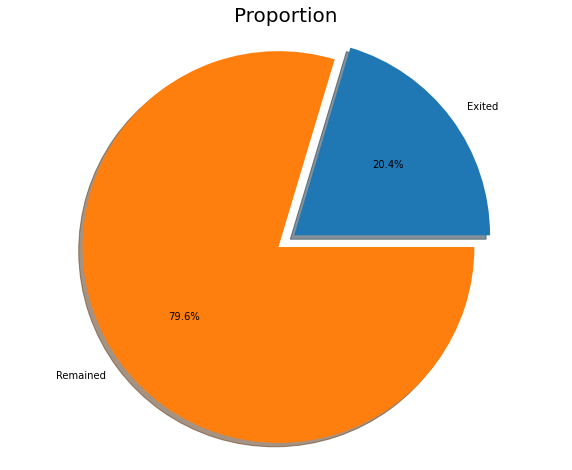

```python
print(data.Exited.value_counts())
labels = 'Exited', 'Remained'
sizes = [data.Exited[data['Exited']==1].count(),data.Exited[data['Exited']==0].count()]
explode = (0, 0.1)
fig1, ax1 = plt.subplots(figsize=(10, 8))
ax1.pie(sizes, explode=explode, labels=labels, autopct='%1.1f%%',
        shadow=True)
ax1.axis('equal')
plt.title("Proportion", size = 20)
plt.show()
```

- 20.4% of the customers exited.
- 79.6% of customers remained.
- So, we have an imbalanced dataset.

```python
data.Exited.value_counts()
```

```
0    7963
1    2037
Name: Exited, dtype: int64
```

```python
df1.info()
```

```
<class 'pandas.core.frame.DataFrame'>
RangeIndex: 10000 entries, 0 to 9999
Data columns (total 11 columns):
 #   Column           Non-Null Count  Dtype
---  ------           --------------  -----
 0   CreditScore      10000 non-null  int64
 1   Geography        10000 non-null  object
 2   Gender           10000 non-null  object
 3   Age              10000 non-null  int64
 4   Tenure           10000 non-null  object
 5   Balance          10000 non-null  float64
 6   NumOfProducts    10000 non-null  object
 7   HasCrCard        10000 non-null  object
 8   IsActiveMember   10000 non-null  object
 9   EstimatedSalary  10000 non-null  float64
 10  Exited           10000 non-null  int64
dtypes: float64(2), int64(3), object(6)
memory usage: 859.5+ KB
```

```python
df2=df1.copy()
```

```python
# Let's drop the outliers describe in previous sections
mask = (df2.CreditScore<360)
df2 = df2.loc[~mask]
```

```python
## Separating Independent and Dependent Columns
X = df2.drop(['Exited'],axis=1)
Y = df2[['Exited']]
```

```python
# Splitting the dataset into the Training and Testing set.

X_train, X_test, y_train, y_test = train_test_split(X,Y, test_size = 0.2, random_state = 42,stratify = Y)
```

```python
X_test_test=X_test.copy()
y_test_test=y_test.copy()
```

```python
df2
```

|  | CreditScore | Geography | Gender | Age | Tenure | Balance | NumOfProducts | HasCrCard | IsActiveMember | EstimatedSalary | Exited |
| --- | --- | --- | --- | --- | --- | --- | --- | --- | --- | --- | --- |
| 0 | 619 | France | Female | 42 | 2 | 0.00 | 1 | 1 | 1 | 101348.88 | 1 |
| 1 | 608 | Spain | Female | 41 | 1 | 83807.86 | 1 | 0 | 1 | 112542.58 | 0 |
| 2 | 502 | France | Female | 42 | 8 | 159660.80 | 3 | 1 | 0 | 113931.57 | 1 |
| 3 | 699 | France | Female | 39 | 1 | 0.00 | 2 | 0 | 0 | 93826.63 | 0 |
| 4 | 850 | Spain | Female | 43 | 2 | 125510.82 | 1 | 1 | 1 | 79084.10 | 0 |
| ... | ... | ... | ... | ... | ... | ... | ... | ... | ... | ... | ... |
| 9995 | 771 | France | Male | 39 | 5 | 0.00 | 2 | 1 | 0 | 96270.64 | 0 |
| 9996 | 516 | France | Male | 35 | 10 | 57369.61 | 1 | 1 | 1 | 101699.77 | 0 |
| 9997 | 709 | France | Female | 36 | 7 | 0.00 | 1 | 0 | 1 | 42085.58 | 1 |
| 9998 | 772 | Germany | Male | 42 | 3 | 75075.31 | 2 | 1 | 0 | 92888.52 | 1 |
| 9999 | 792 | France | Female | 28 | 4 | 130142.79 | 1 | 1 | 0 | 38190.78 | 0 |

9992 rows × 11 columns

### Encoding Categorical Columns

```python
from sklearn.preprocessing import LabelEncoder
labelencoder_GEO = LabelEncoder()
X_train['Geography']= labelencoder_GEO.fit_transform(X_train['Geography'])
X_test['Geography']= labelencoder_GEO.transform(X_test['Geography'])
```

```python
labelencoder_GEN = LabelEncoder()
X_train['Gender'] =  labelencoder_GEN.fit_transform(X_train['Gender'])
X_test['Gender'] =  labelencoder_GEN.transform(X_test['Gender'])
```

```python
X_train = pd.get_dummies(X_train,columns= cat_features,drop_first =True)
X_test = pd.get_dummies(X_test,columns=cat_features,drop_first =True)
```

```python
X_train
```

|  | CreditScore | Age | Balance | EstimatedSalary | Geography_1 | Geography_2 | Gender_1 | Tenure_1 | Tenure_2 | Tenure_3 | Tenure_4 | Tenure_5 | Tenure_6 | Tenure_7 | Tenure_8 | Tenure_9 | Tenure_10 | NumOfProducts_2 | NumOfProducts_3 | NumOfProducts_4 | HasCrCard_1 | IsActiveMember_1 |
| --- | --- | --- | --- | --- | --- | --- | --- | --- | --- | --- | --- | --- | --- | --- | --- | --- | --- | --- | --- | --- | --- | --- |
| 3313 | 684 | 54 | 0.00 | 94888.60 | 0 | 0 | 1 | 0 | 0 | 0 | 0 | 0 | 1 | 0 | 0 | 0 | 0 | 1 | 0 | 0 | 1 | 1 |
| 7499 | 609 | 71 | 113317.10 | 108258.22 | 1 | 0 | 0 | 0 | 0 | 0 | 0 | 0 | 1 | 0 | 0 | 0 | 0 | 0 | 0 | 0 | 1 | 0 |
| 4002 | 634 | 29 | 130036.21 | 69849.55 | 1 | 0 | 0 | 0 | 0 | 0 | 0 | 0 | 0 | 0 | 1 | 0 | 0 | 1 | 0 | 0 | 0 | 1 |
| 5630 | 621 | 37 | 83061.26 | 9170.54 | 0 | 1 | 0 | 0 | 0 | 0 | 0 | 0 | 0 | 0 | 0 | 1 | 0 | 1 | 0 | 0 | 1 | 0 |
| 9153 | 507 | 36 | 118214.32 | 119110.03 | 1 | 0 | 1 | 0 | 0 | 0 | 0 | 0 | 0 | 0 | 0 | 1 | 0 | 0 | 1 | 0 | 1 | 0 |
| ... | ... | ... | ... | ... | ... | ... | ... | ... | ... | ... | ... | ... | ... | ... | ... | ... | ... | ... | ... | ... | ... | ... |
| 1176 | 726 | 34 | 0.00 | 14121.61 | 0 | 0 | 1 | 0 | 0 | 0 | 0 | 0 | 0 | 0 | 0 | 1 | 0 | 1 | 0 | 0 | 0 | 0 |
| 3117 | 721 | 43 | 88798.34 | 45610.63 | 0 | 1 | 1 | 0 | 0 | 1 | 0 | 0 | 0 | 0 | 0 | 0 | 0 | 0 | 0 | 0 | 0 | 0 |
| 6435 | 700 | 26 | 119009.57 | 141926.43 | 0 | 0 | 1 | 0 | 0 | 0 | 1 | 0 | 0 | 0 | 0 | 0 | 0 | 0 | 0 | 0 | 1 | 0 |
| 2203 | 613 | 30 | 111927.45 | 175795.87 | 0 | 1 | 1 | 0 | 0 | 0 | 0 | 0 | 0 | 0 | 0 | 1 | 0 | 0 | 0 | 0 | 1 | 1 |
| 4121 | 628 | 42 | 0.00 | 172967.87 | 0 | 1 | 1 | 0 | 0 | 0 | 0 | 0 | 0 | 1 | 0 | 0 | 0 | 1 | 0 | 0 | 0 | 1 |

7993 rows × 22 columns

```python
# Scaling the data set
from sklearn.preprocessing import MinMaxScaler,StandardScaler

scaler = MinMaxScaler()
```

```python
## Scaling the data
temp = scaler.fit(X_train[["CreditScore","Age","Balance","EstimatedSalary"]])
X_train[["CreditScore","Age","Balance","EstimatedSalary"]] = temp.transform(X_train[["CreditScore","Age","Balance","EstimatedSalary"]])
X_test[["CreditScore","Age","Balance","EstimatedSalary"]] = temp.transform(X_test[["CreditScore","Age","Balance","EstimatedSalary"]])
```

```python
X_train
```

|  | CreditScore | Age | Balance | EstimatedSalary | Geography_1 | Geography_2 | Gender_1 | Tenure_1 | Tenure_2 | Tenure_3 | Tenure_4 | Tenure_5 | Tenure_6 | Tenure_7 | Tenure_8 | Tenure_9 | Tenure_10 | NumOfProducts_2 | NumOfProducts_3 | NumOfProducts_4 | HasCrCard_1 | IsActiveMember_1 |
| --- | --- | --- | --- | --- | --- | --- | --- | --- | --- | --- | --- | --- | --- | --- | --- | --- | --- | --- | --- | --- | --- | --- |
| 3313 | 0.659138 | 0.486486 | 0.000000 | 0.474224 | 0 | 0 | 1 | 0 | 0 | 0 | 0 | 0 | 1 | 0 | 0 | 0 | 0 | 1 | 0 | 0 | 1 | 1 |
| 7499 | 0.505133 | 0.716216 | 0.475348 | 0.541105 | 1 | 0 | 0 | 0 | 0 | 0 | 0 | 0 | 1 | 0 | 0 | 0 | 0 | 0 | 0 | 0 | 1 | 0 |
| 4002 | 0.556468 | 0.148649 | 0.545482 | 0.348968 | 1 | 0 | 0 | 0 | 0 | 0 | 0 | 0 | 0 | 0 | 1 | 0 | 0 | 1 | 0 | 0 | 0 | 1 |
| 5630 | 0.529774 | 0.256757 | 0.348430 | 0.045425 | 0 | 1 | 0 | 0 | 0 | 0 | 0 | 0 | 0 | 0 | 0 | 1 | 0 | 1 | 0 | 0 | 1 | 0 |
| 9153 | 0.295688 | 0.243243 | 0.495891 | 0.595390 | 1 | 0 | 1 | 0 | 0 | 0 | 0 | 0 | 0 | 0 | 0 | 1 | 0 | 0 | 1 | 0 | 1 | 0 |
| ... | ... | ... | ... | ... | ... | ... | ... | ... | ... | ... | ... | ... | ... | ... | ... | ... | ... | ... | ... | ... | ... | ... |
| 1176 | 0.745380 | 0.216216 | 0.000000 | 0.070192 | 0 | 0 | 1 | 0 | 0 | 0 | 0 | 0 | 0 | 0 | 0 | 1 | 0 | 1 | 0 | 0 | 0 | 0 |
| 3117 | 0.735113 | 0.337838 | 0.372496 | 0.227714 | 0 | 1 | 1 | 0 | 0 | 1 | 0 | 0 | 0 | 0 | 0 | 0 | 0 | 0 | 0 | 0 | 0 | 0 |
| 6435 | 0.691992 | 0.108108 | 0.499227 | 0.709528 | 0 | 0 | 1 | 0 | 0 | 0 | 1 | 0 | 0 | 0 | 0 | 0 | 0 | 0 | 0 | 0 | 1 | 0 |
| 2203 | 0.513347 | 0.162162 | 0.469519 | 0.878958 | 0 | 1 | 1 | 0 | 0 | 0 | 0 | 0 | 0 | 0 | 0 | 1 | 0 | 0 | 0 | 0 | 1 | 1 |
| 4121 | 0.544148 | 0.324324 | 0.000000 | 0.864811 | 0 | 1 | 1 | 0 | 0 | 0 | 0 | 0 | 0 | 1 | 0 | 0 | 0 | 1 | 0 | 0 | 0 | 1 |

7993 rows × 22 columns

```python
###Checking the shape of train and test sets
print(X_train.shape)
print(X_test.shape)
print(y_train.shape)
print(y_test.shape)
```

```
(7993, 22)
(1999, 22)
(7993, 1)
(1999, 1)
```

**Model Building**

- A model can make wrong predictions in the following ways: Predicting a customer left the bank, when he/she remained with the bank, or vice versa.

*Which case is more important?*

- Both cases are actually important for the purposes of this case study. Not giving a chance to a deserving customer (by wrongly classifying them as likely to attrite) might lead to decreased productivity, and the bank might lose a good customer affecting the bank's growth. However, giving chances to a non-deserving customer (as they are likely to attrite) would lead to a financial loss for the company, and giving such customers increased opportunities or offers might again affect the bank's growth.
- How to reduce this loss i.e need to reduce False Negatives as well as False Positives? Since both errors are important for us to minimize, the bank would want the F1 Score evaluation metric to be maximized. Hence, the focus should be on increasing the F1 score rather than focusing on just one metric i.e. Recall or Precision.